# Practicum 1: R and RStudio

Data Science for Biomedical Informatics (BMIN503/EPID600)

## Introduction

The purpose of this practicum is to install R and RStudio, the primary software that we will use throughout the course. Rather than work with servers or virtual machines that have pre-installed software, we will install programs and packages, as doing so is a required skill in data science. Completion of the steps below is also necessary for future coursework.

## Install R and RStudio

- Go to https://posit.co/download/rstudio-desktop/#download
- Follow step 1 to install [R](https://cran.r-project.org/) for your operating system.
- Follow step 2 to install RStudio for your operating system.
- Open RStudio.

## RStudio Overview

RStudio is a free R user interface that makes development of code and integration of R files with reproducible research tools very straightforward. Explore the RStudio windows and tabs. In the R Console, you can type and execute R commands directly. For example, try these commands in the Console (in the html file, you should type in the commands in boxes, and the output should be what appears after the boxes):

```r
1 + 2
```

```
[1] 3
```

```r
c(1:5)
```

```
[1] 1 2 3 4 5
```

```r
cat("hello", "there")
```

```
hello there
```

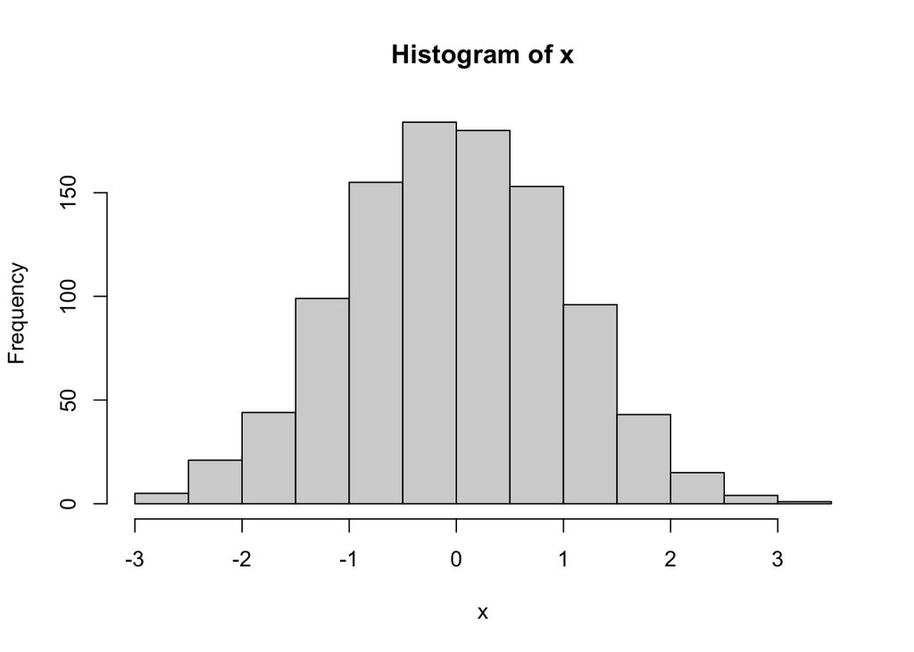

```r
x <- rnorm(1000)
hist(x)
```

We will discuss R commands in more detail later. You can open R scripts, Quarto Documents (.qmd), and various other types of files in the text editor that is above the console as we will see below. The Terminal window (tab adjacent to the Console) is the one we will use to execute git commands next class. To the right, there are windows that show variables loaded (i.e., Environment), history of commands, connections (e.g., via git), file path navigation (i.e., Files), plot output (i.e., Plots), package installation (i.e., Packages), and R documentation (i.e., Help).

### R Settings

There are some Console commands that you should become familiar with for when you are working with R on a server or within scripts. The current *working directory*, where your data is read and saved to can be checked by typing the following in the Console:

```r
getwd()
```

To see what files are in this current directory:

```r
dir()
```

To see what functions are loaded:

```r
ls()
```

To change directories, you can use `setwd()` within the command line or in an R script. With RStudio, we can use GUI tools to do all of the above. For example, you can change directories by browsing to one: go to Session -> Set Working Directory -> Choose Directory, then select a new directory. Alternatively, you can use the “Files” panel on the bottom right of RStudio. If you log in to a Unix server and have to use R on its own, then commands such as the above may become useful to run scripts.

### R Packages

Many of the R functions we use are in packages, which have to be installed and loaded prior to use. From the R console, install these packages from CRAN:

```r
install.packages("knitr")
install.packages("rmarkdown")
install.packages("tidyverse")
```

In RStudio, packages can be installed interactively with the “Install Packages” tool in the “Packages” tab. Once packages are installed, it is necessary to tell R about them each time you start an R session or include them within a script where they are used with the `library()` command:

```r
library(tidyverse)
```

To see currently loaded packages, you can find them under the “Global Environment” option in the Environment tab. From the Console, you can use the `search()` function to see loaded packages. RStudio will recognize that there are uninstalled packages if you open a .qmd file with a `library()` call to a package that isn’t installed and prompt you to install it.

### Help in R

To get help about specific R functions, type `?` before the command. In RStudio, the effect of this will be to open the `Help` window with documentation for that specific command.

```r
?read.table
```

More broadly, when you don’t know the name of the command you are looking for, you can use the following command to do a text search through the R documentation:

```r
help.search("average")
```

Goolge searches often locate answers to problems encountered and can be used to look up functions. Use `sessionInfo()` when asking a question about R either by email or to a forum. This helps others understand the environment where a problem arises. Tools like ChatGPT can provide very helpful responses to questions and provide step-by-step instructions to solve issues, but note that you will have to become proficient enough with R to use results from such a tool effectively.

### R Scripts

Any text editor can be used to edit R files, including the one that is available in RStudio. We will use RStudio to edit text files with R commands. *R script* files (.R ending) consist of R functions, comments, and variables. To create a new R script file, use the RStudio new document icon in the upper-left-hand corner and select “R Script”. In the new document, type the following:

```r
#Test R script
x <- 1
y <- 2
x + y
```

Now save the file as `test.R`. To execute the code, click on “Run” above the text editor window. Note that the single line where the cursor is located is run by default. You can select multiple lines of code and then click “Run” to execute more than one line. To run the entire document, you can select “Source” instead. The line that begins with a hash is a comment. When writing scripts or computer code, comments are very helpful to document characteristics about the code (e.g., its goal). Alternatively, you can load an R script into your R environment at the command line by typing:

```r
source("test.R")
```

As written, the command would require that test.R is located in the working directory. Verify that the contents of `test.R` loaded properly by typing `x` and `y` at the command line. You can modify their values in the document and repeat the steps to see their values change.

### Quarto Documents

For class, we will use [Quarto Documents](https://quarto.org) (.qmd ending) since these are easily converted into visually appealing output documents that include text, graphics, and code. Within a Quarto Document, we can combine text that is written with Markdown, a markup language that describes how text should look on a page, with chunks of code that are written and executed in R. To execute R code directly within files, we can use the “Run” button in the menu bar, the green arrow above a code chunk, or Cmd+Enter (Mac) or Ctrl+Enter (Windows) on a set of code lines. The Quarto Documents can be converted into various output types, including html, by rendering them with the “Render” command. Such documents are a great way to keep a “lab notebook” for data science projects.

To create a new Quarto Document, use the RStudio new document icon in the upper-left-hand corner and select “Quarto Document…”. Give it a title of your choice (or leave the default options) and click “OK”. The new document has some sample text and commands that illustrate some of the main components of a Quarto Document file. To save the file, use File -> Save As, and then choose a `test.qmd` and click “Save”. Click on the “Render” icon at the top of the file to generate an html document based on the template and compare the two.

You can edit the Quarto Document in “Visual” mode to see the Markdown displayed as it would be in the final document, or you can edit in the “Source” mode with Markdown code. If you are not familiar with Markdown, you can view a short guide under Help->Markdown Quick Reference menu of RStudio or read more about how R can be used with Markdown [here](http://rmarkdown.rstudio.com). The Quarto Documents we will use are an enhanced version of R Markdown documents (.Rmd) that work with other programming languages such as Python and have enhanced features like support of Figure and Table labels. To learn more about Quarto, start [here](https://quarto.org).